# MovieLens Rating Prediction Project

The dataset has around 70000 unique users.

```r
edx %>%
summarize(users = n_distinct(userId))
```

| users |
| --- |
| 69878 |

The dataset has around 10000 unique movies.

```r
edx %>%
summarize(users = n_distinct(title))
```

| users |
| --- |
| 10407 |

The release years of movies in the dataset range 1915 to 2008. Though, most movies belong to years 1980-2000.

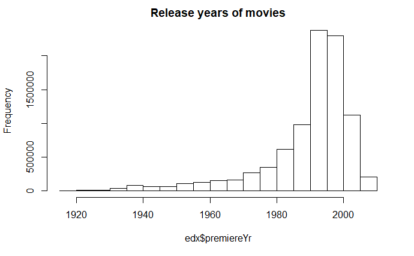

```r
hist(edx$premiereYr, main="Release years of movies", fill="cadetblue")
```

We observe that the span of ratings data is around 14 years, which makes this dataset unbiased.

```r
library(lubridate)
years<-format(edx$timestamp, format="%Y")
as.numeric(max(years))-as.numeric(min(years))
```

```
[1] 14
```

```r
#duration(max(edx$timestamp)- min(edx$timestamp))
```

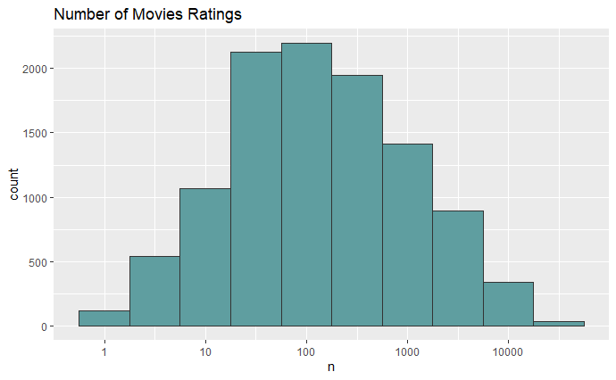

```r
#Distribution of Movie Ratings
edx %>% group_by(movieId) %>% summarize(n = n()) %>%
  ggplot(aes(n)) + geom_histogram(fill = "cadetblue", color = "grey20", bins = 10) +
  scale_x_log10() +
  ggtitle("Number of Movies Ratings")
```

The ratings of the movies can have half or full stars. The rating distribution indicates that most movies get full star ratings. Moreover, there is a tendency that users generally rate movies between 3 and 4.

```r
print("Frequencies of ratings")
```

```
[1] "Frequencies of ratings"
```

```r
sort(table(edx$rating))
```

```
    0.5     1.5     2.5       1     4.5       2     3.5       5       3       4
  85420  106379  332783  345935  526309  710998  792037 1390541 2121638 2588021
```

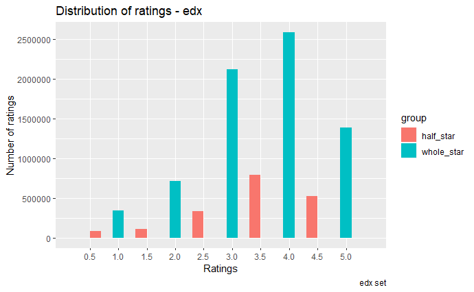

```r
# Pplotting graph
group <-  ifelse((edx$rating == 1 |edx$rating == 2 | edx$rating == 3 |
                  edx$rating == 4 | edx$rating == 5) ,
                   "whole_star",
                   "half_star")

ratings_distribution <- data.frame(edx$rating, group)
ggplot(ratings_distribution, aes(x= edx.rating, fill = group)) +
  geom_histogram( binwidth = 0.2) +
  scale_x_discrete(limits = c(seq(0.5,5,0.5))) +
  scale_y_continuous(breaks = c(seq(0, 3000000, 500000)))+
  labs(x="Ratings", y="Number of ratings", caption = "edx set") +
  ggtitle("Distribution of ratings - edx")
```

This information is important for our model because a very low rating numbers can result in less precise estimate of our predictions. We may have to use regularisation to solve this issue. Regularisation is a technique used for tuning the function by adding an additional penalty term in the error function.

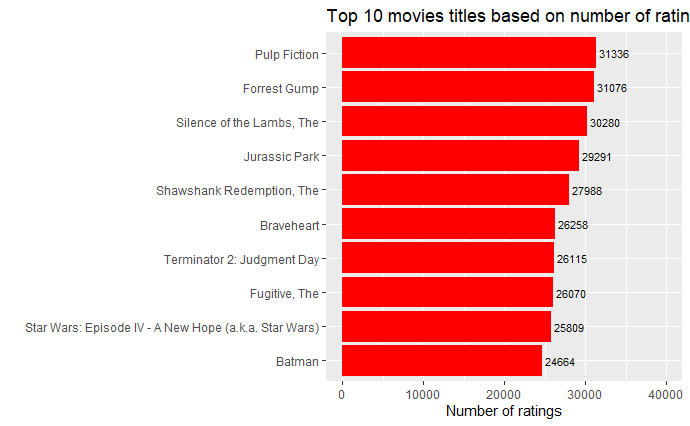

```r
top_movies <- edx %>%
  group_by(title) %>%
  summarize(count=n()) %>%
  top_n(10) %>%
  arrange(desc(count))
top_movies %>%
  ggplot(aes(x=reorder(title, count), y=count)) +
  geom_bar(stat='identity', fill="red") + coord_flip(y=c(0, 40000)) +
  labs(x="", y="Number of ratings") +
  geom_text(aes(label= count), hjust=-0.1, size=3) +
  labs(title="Top 10 movies titles based on number of ratings" )
```

Bottom 10 movies that are rated once only appear to be obscure. So predictions for future ratings for such movies will be difficult.

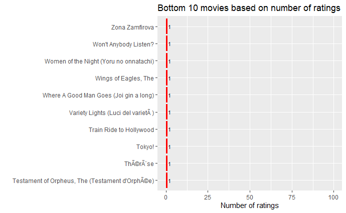

```r
bottom_movies <- edx %>%
  group_by(title) %>%
  summarize(count=n()) %>%
  arrange(desc(count))

bottom_movies %>% tail(10) %>%
  ggplot(aes(x=reorder(title, count), y=count)) +
  geom_bar(stat='identity', fill="red") + coord_flip(y=c(0, 100)) +
  labs(x="", y="Number of ratings") +
  geom_text(aes(label= count), hjust=-0.1, size=3) +
  labs(title="Bottom 10 movies based on number of ratings")
```

```r
sprintf("Movies with a single rating = %d",sum(bottom_movies$count==1))
```

```
[1] "Movies with a single rating = 120"
```

We observe that most users rate movies between 30 and 100. So, it will also be a good idea to use a user penalty term in our model.

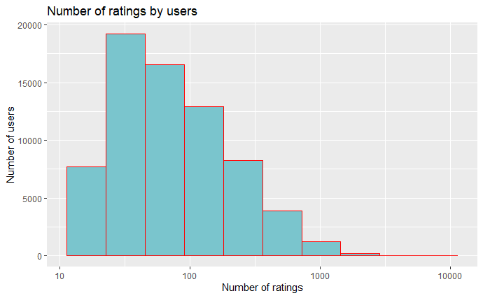

```r
edx %>%
  count(userId) %>%
  ggplot(aes(n)) +
  geom_histogram(bins = 10, col = "red",  fill="cadetblue3") +
  scale_x_log10() +
  xlab("Number of ratings") +
  ylab("Number of users") +
  ggtitle("Number of ratings by users")
```

The exploration of ‘genere’ indicates that most movies belong to Drama and Comedy generes.Very few movies belong to horror genere.

```r
generes <- c("Drama","Comedy","Thriller","Romance","Sci-Fi","Adventure","Action","Horror")
sapply(generes, function(x)
{
 sprintf("%s = %d",x,sum(grepl(x,edx$genres)))
}
)
```

```
                Drama                Comedy              Thriller               Romance
    "Drama = 3909401"    "Comedy = 3541284"  "Thriller = 2325349"   "Romance = 1712232"
               Sci-Fi             Adventure                Action                Horror
   "Sci-Fi = 1341750" "Adventure = 1908692"    "Action = 2560649"     "Horror = 691407"
```